# Comparison of the Computational Costs of Various Sampling and Prediction Methods for Gaussian Processes with Matérn Covariance Functions

David Bolin, Vaibhav Mehandiratta, and Alexandre B. Simas

Created: 2024-05-20. Last modified: 2024-05-21.

## Introduction

This vignette contains some time comparisons for sampling and doing prediction of stationary Gaussian processes with the Matérn covariance function
$$r(h) =
\frac{\sigma^2}{2^{\nu-1}\Gamma(\nu)}(\kappa h)^\nu K_\nu(\kappa
h),$$
where $\Gamma(\cdot)$ is the Gamma function and $K_\nu$ is the modified Bessel function of the second kind, $\kappa$ is connected to the range of the process, $\nu$ is the smoothness parameter and $\sigma$ is the marginal standard deviation. We will consider some approximations, the reference approximation is the one based on the method introduced in (Bolin, Mehandiratta, and Simas, n.d.). We will compare it against a singular value decomposition method (PCA) and a nearest neighbor approach (Datta et al. 2016). We will use a calibration of the hyperparameter $m$ introduced in (Bolin, Mehandiratta, and Simas, n.d.) based on the theoretical costs obtained in Table 1 of (Bolin, Mehandiratta, and Simas, n.d.).

## Preprocessing

We start by installing the newest version of rSPDE to make sure all the functions we will are are available.

```r
devtools::install_github("davidbolin/rSPDE")
```

We will now load all the auxiliary functions:

```r
source("aux_functions/aux_functions_cov.R")
source("aux_functions/predict_methods.R")
source("aux_functions/simulate_methods.R")
```

## Cost comparison based on predictions

For this case we will consider that we have $N=1000$ observations, the range parameter will be $0.2$, the standard deviation will be $1$. The cost will be measured for the smoothness parameter $\nu$ between $0$ and $0.5$, and between $0.5$ and $1.5$. The hyperparameter of the model will be $m$ taken from 1 to 6 for the reference method, and calibrated following Table 1 of (Bolin, Mehandiratta, and Simas, n.d.) for the PCA method and nearest neighbor methods.

We start by defining the parameters:

```r
N <- 1000
range =0.2
sigma = 1
samples = 10
m <- 1:6
```

We will now compute the times based on prediction by using the `compare_times()` function:

```r
times <- compare_times(N = N, m = m, range = range, sigma = sigma, samples = 100)
```

Let us now plot the results to observe that the costs are, in fact, similar:

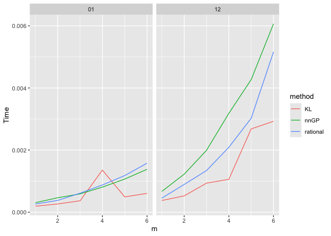

```r
library(dplyr)
library(ggplot2)

times |> ggplot() + geom_line(aes(x = m, y = Time, col = method)) + facet_wrap(~alpha)
```

## Cost comparison based on sampling

We will now compare the times for the same choices of parameters by using the `compare_times_simulation()` function:

```r
times <- compare_times_simulation(N = N, m = m, range = range, sigma = sigma, nsim = 1, samples = 100)
```

Let us now plot the results:

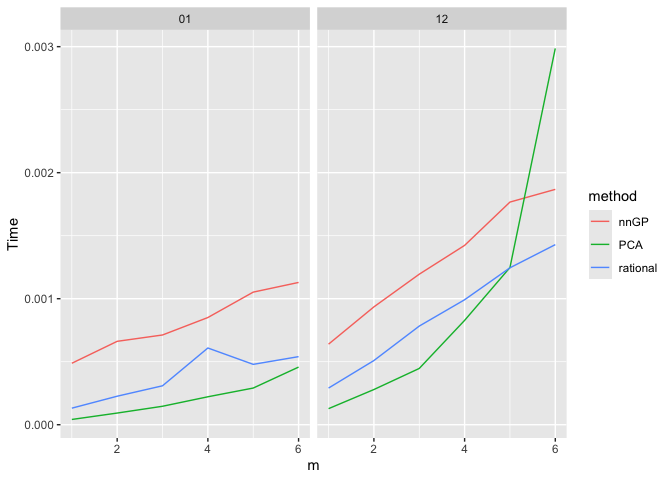

```r
times |> filter(N == 1000) |> ggplot() + geom_line(aes(x = m, y = Time, col = method)) + facet_wrap(~alpha)
```

Bolin, David, Vaibhav Mehandiratta, and Alexandre B. Simas. n.d. “Linear Cost and Exponentially Convergent Approximation of Gaussian Matérn Stochastic Processes.” *Preprint*.

Datta, A., S. Benerjee, A. O. Finley, and A. E. Gelfand. 2016. “Hierarchical Nearest-Neighbor Gaussian Process Models for Large Geostatistical Datasets.” *J. Amer. Statist. Assoc.*